# Unsupervised Learning

11/26/2019

## Agenda

- Introduction
- K-means
- Gaussian mixture model
- Hierarchical clustering
- Principal Component Analysis (PCA)

## Recap

## Unsupervised learning

We have seen a lot of models for \(y \mid x\). This is called **supervised learning** (we explain the relationship between \(x\) and a special chosen variable \(y\)).

Now we will see models for \(x\) alone.

- This generally means that analysis goals are not clearly defined and we cannot directly validate the findings (no such thing as RSS)
- However, there are still many important questions that we can consider:
  - Is there an informative way to **visualize** the data?
  - Can we discover **subgroups** among the variables or among the observations?
  - Is there any hidden **pattern** in the data?

## Hierarchical clustering

## Main difference with \(K\)-means

\(K\)-means clustering and basic mixture models require us to pre-specify the number of clusters \(K\).

Hierarchical clustering:

- is an alternative approach which does not require that we commit to a particular choice of \(K\)
- produces a set of nested clusters organized hierarchically
- can be visualized as a “dendrogram”, a tree-like diagram that records the sequences of merges or splits

We describe bottom-up or agglomerative clustering: common type of hierarchical clustering, it refers to the fact that a dendrogram is built starting from the leaves and combining clusters up to the trunk.

## Algorithm steps

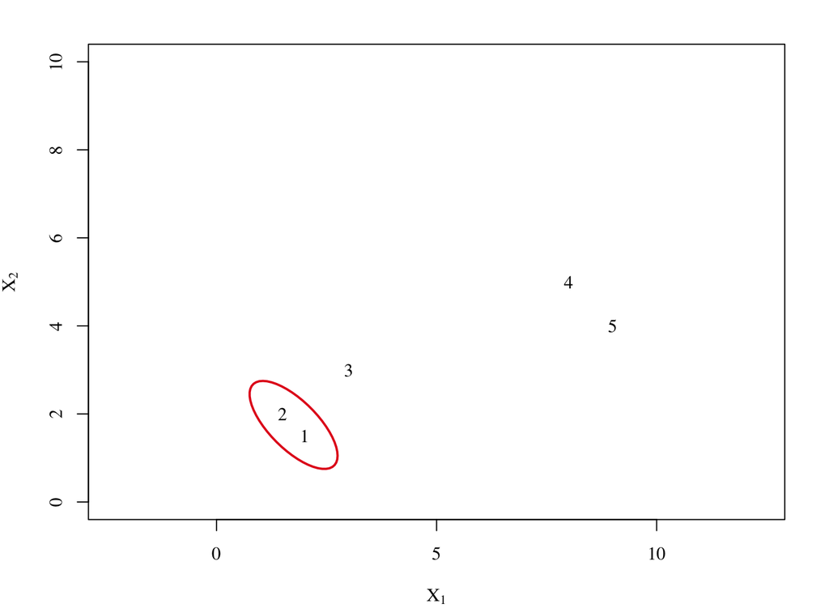

## Algorithm steps

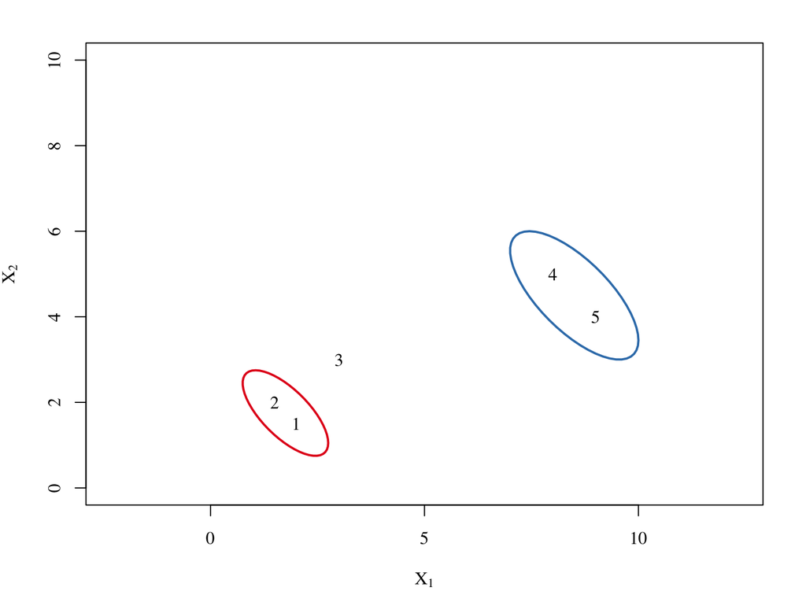

## Algorithm steps

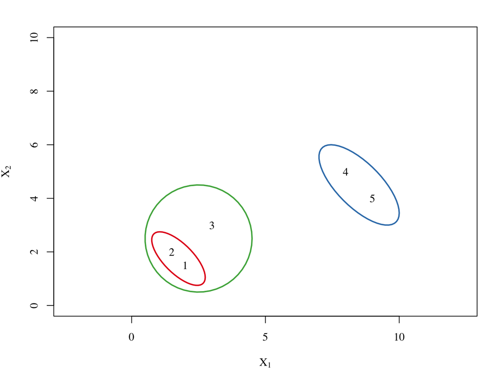

## Algorithm steps

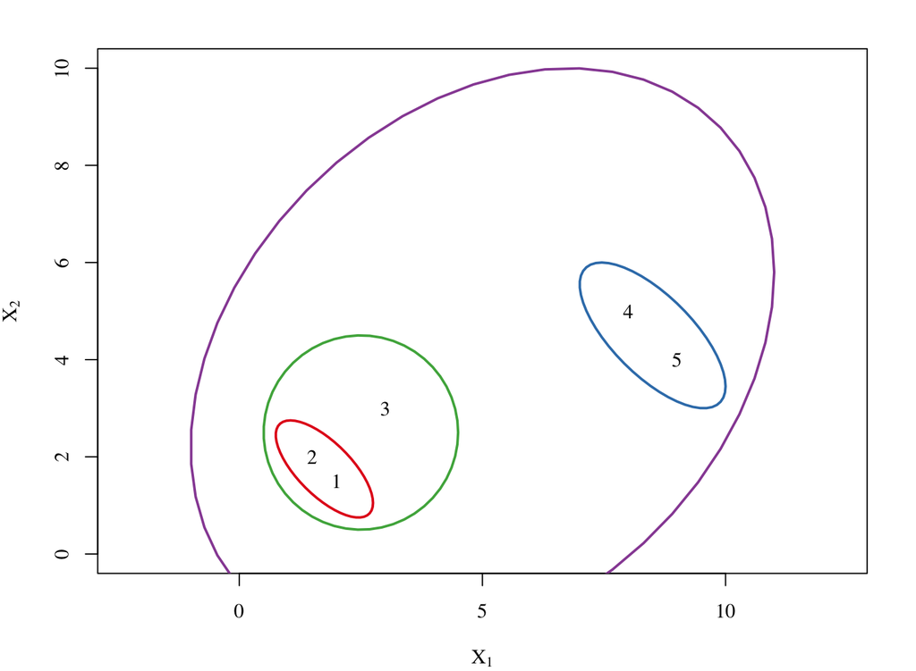

## Algorithm steps

1. Start with each point in its own cluster
2. Identify the “closest” two clusters and merge them
3. Repeat
4. Ends when all points are in a single cluster

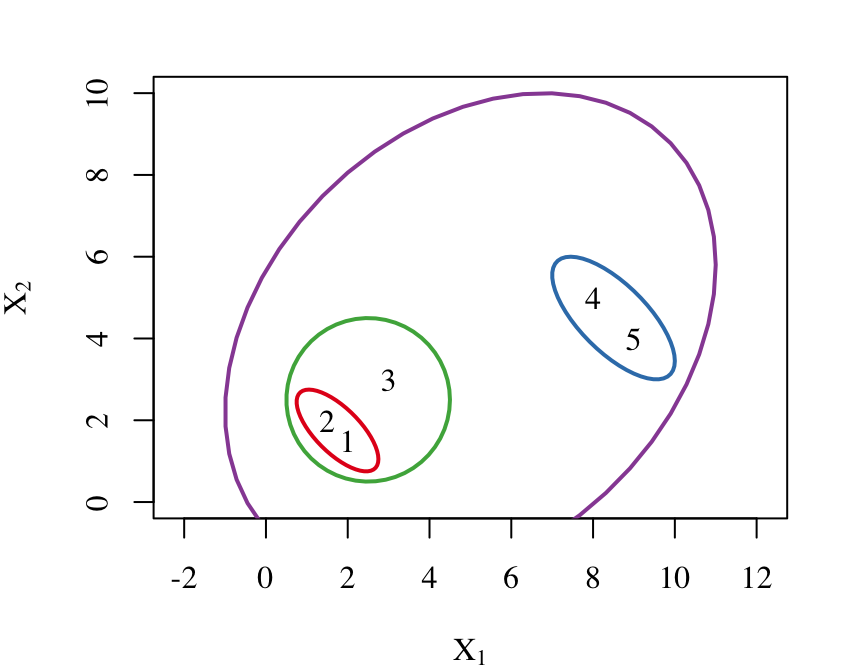

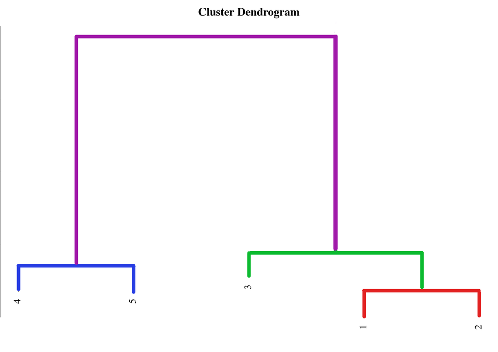

## Choose the number of clusters

\[K = 3\]

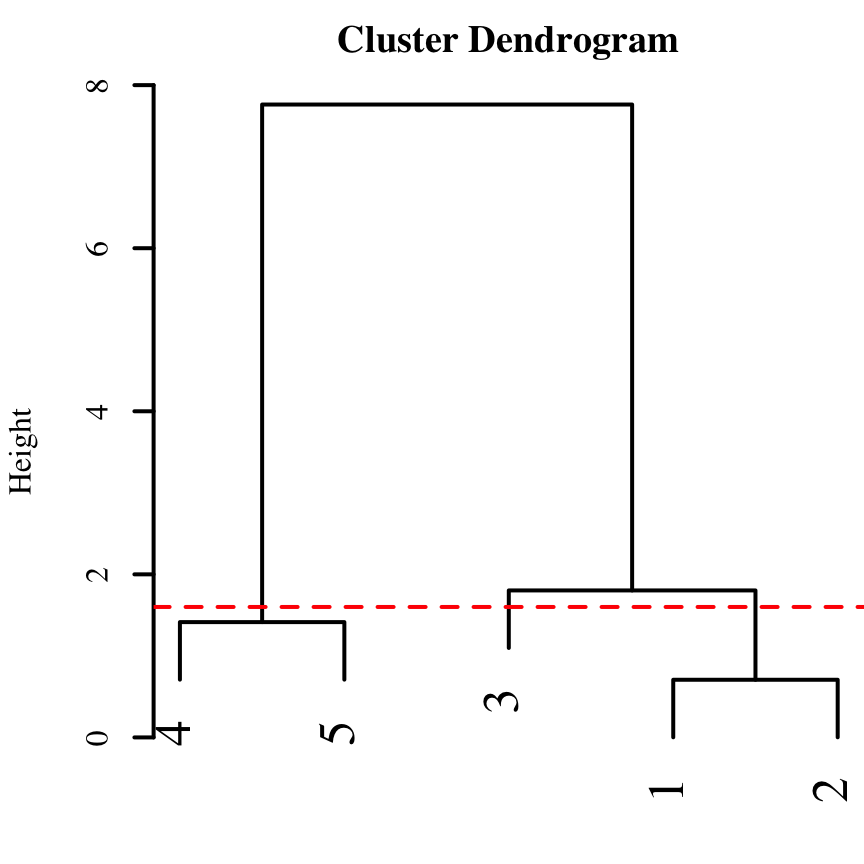

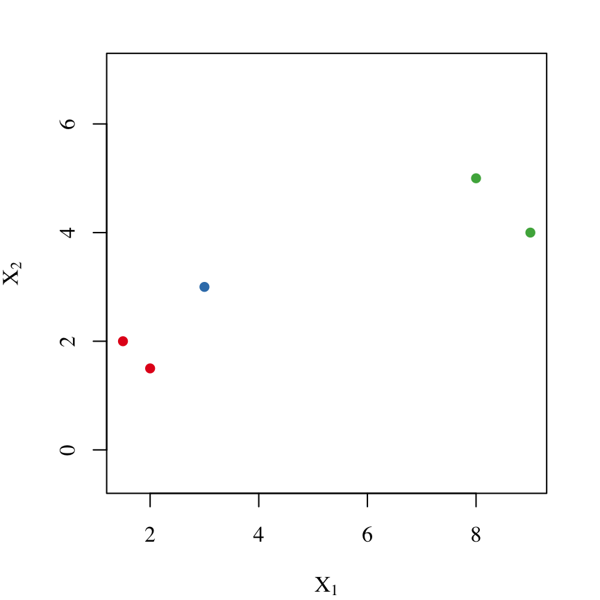

## Choose the number of clusters

\[K = 2\]

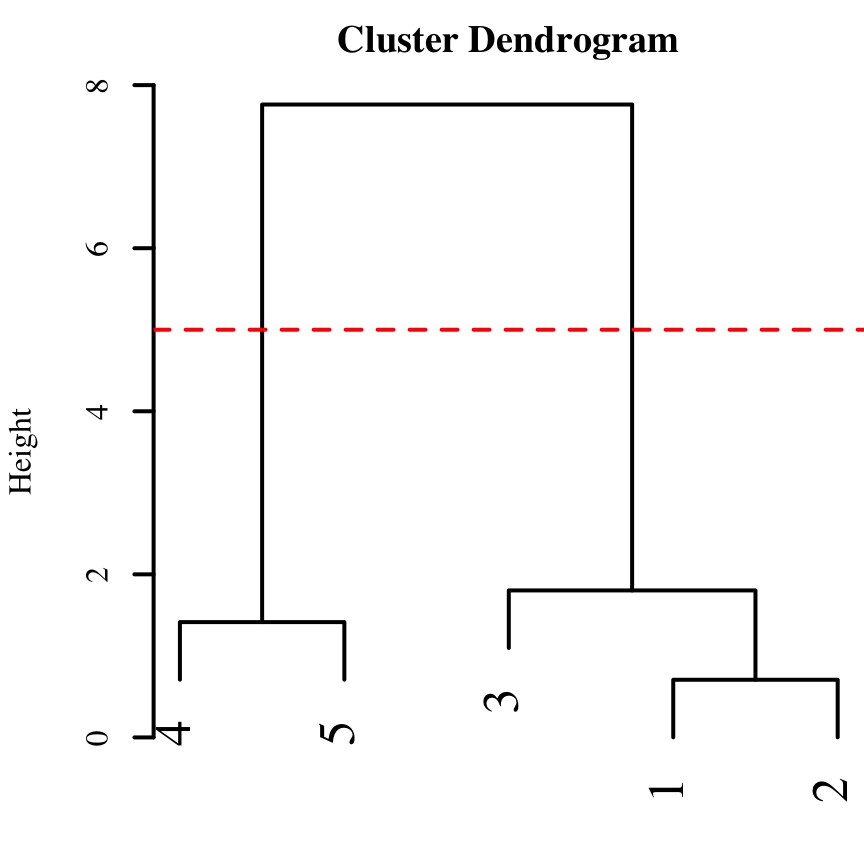

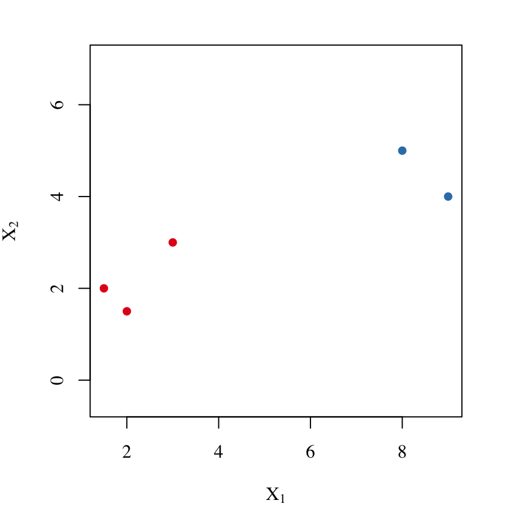

## Types of linkage

What does “closest two clusters” mean? How do we measure similarity/distance between two clusters of points?

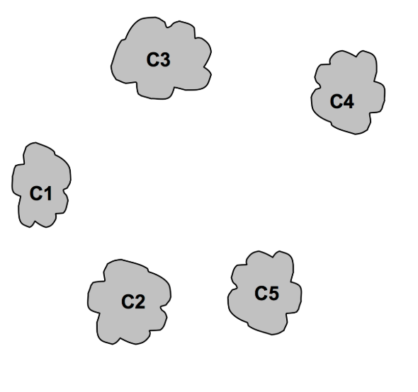

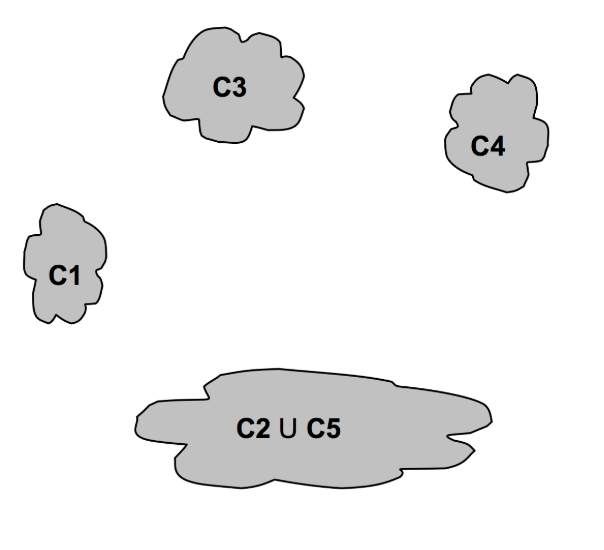

.

Four obvious options: min, max, average, centroids. There are called **linkage functions**.

## Complete linkage

Maximal inter-cluster dissimilarity: compute all pairwise dissimilarities between the observations in cluster A and the observations in cluster B, and record the largest of these dissimilarities.

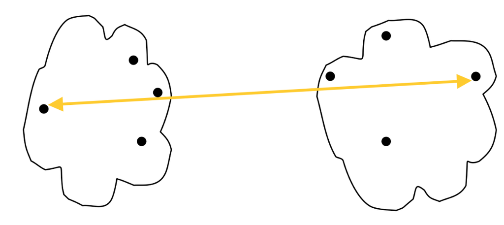

## Single linkage

Minimal inter-cluster dissimilarity: compute all pairwise dissimilarities between the observations in cluster A and the observations in cluster B, and record the smallest of these dissimilarities.

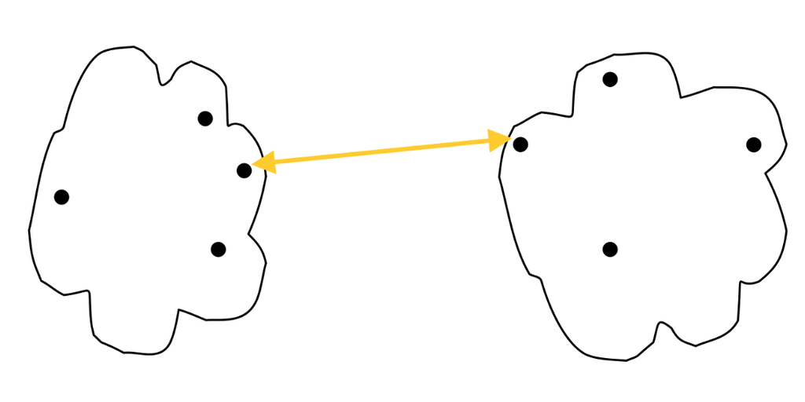

## Average linkage

Mean inter-cluster dissimilarity: compute all pairwise dissimilarities between the observations in cluster A and the observations in cluster B, and record the average of these dissimilarities.

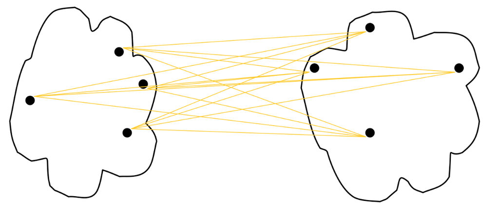

## Centroid linkage

Dissimilarity between the centroid for cluster A (a mean vector of length \(p\)) and the centroid for cluster B.

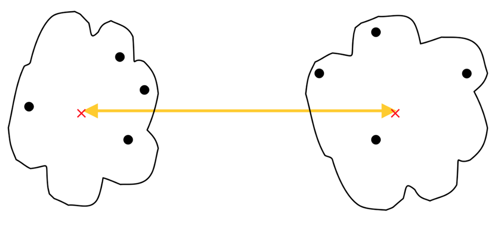

## Types of linkage

Each linkage has its own pros and cons:

- Min: more sensitive to noise and outliers, but will leave large, obvious clusters mostly intact
- Max: more robust to noise and outliers, but tends to break up large clusters
- Average and centroid: kind of a compromise between the two

## Principal Components Analysis (PCA)

## Main goal

- Principal component analysis (PCA) produces a low-dimensional representation of a dataset
- It finds a sequence of linear combinations of the variables that have maximal variance, and are mutually uncorrelated
- Apart from producing derived variables for use in supervised learning problems, PCA also serves as a tool for **data visualization**

## PCA: details

- The first principal component (PC1) of a set of features \(X_1,\dots, X_p\) is the normalized linear combination of the features \[Z_1 = \phi_{11} X_1 + \phi_{21} X_2 +\dots + \phi_{p1} X_p\] that has the largest variance. By normalized, we mean that \(\sum_{j=1}^{p} \phi_{j1}^2 = 1\)
- We refer to the elements \(\phi_{11}, \dots, \phi_{p1}\) as the loadings of the first principal component; together, the loadings make up the principal component loading vector, \(\phi_1 = (\phi_{11}, \dots, \phi_{p1})^\intercal\)
- We constrain the loadings so that their sum of squares is equal to one, since otherwise setting these elements to be arbitrarily large in absolute value could result in an arbitrarily large variance

## Example

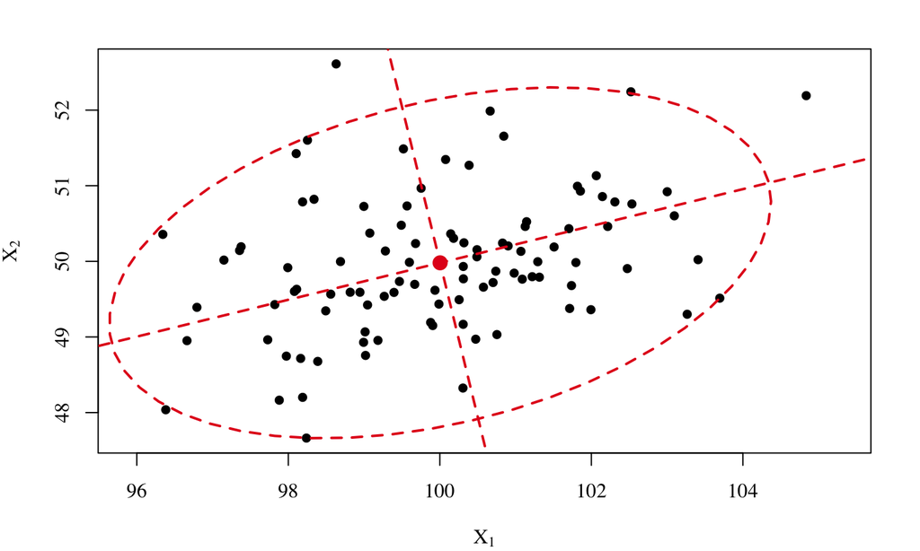

## Example

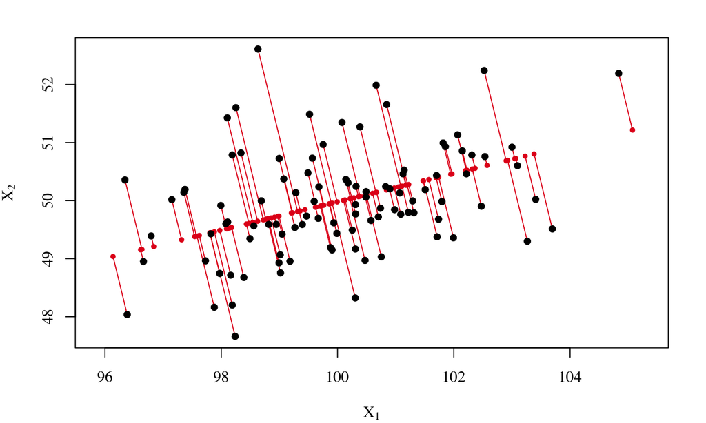

## How to find the Principal Components

- Suppose we have a \(n \times p\) data set \(X\). Since we are only interested in variance, we assume that each of the variables in \(X\) has been centered to have mean zero
- We then look for the linear combination of the sample feature values of the form \[z_{i1} = \phi_{11} x_{i1} + \phi_{21} x_{i2} +\dots + \phi_{p1} x_{ip}\] for \(i = 1, \dots, n\) that has largest sample variance, subject to the constraint that \(\sum_{j=1}^{p} \phi_{j1}^2 = 1\)
- Since each of the \(x_{ij}\) has mean zero, then so does \(z_{i1}\). Hence the sample variance of \(z_{i1}\) can be written as \(\frac{1}{n} \sum_{i=1}^{n} z_{i1}^2\)

## How to find the Principal Components

- Thus, the first principal component loading vector solves the optimization problem \[\begin{aligned} &\text{argmax}_{\phi_{11},\dots,\phi_{p1}} \frac{1}{n} \sum_{i=1}^{n} \left( \phi_{11} x_{i1} + \phi_{21} x_{i2} +\dots + \phi_{p1} x_{ip} \right)^2 \\ &\text{subject to } \sum_{j=1}^{p} \phi_{j1}^2 = 1 \end{aligned}\]
- This problem can be solved via a singular-value decomposition of the matrix \(X\), a standard technique in linear algebra
- We refer to \(Z_1\) as the first principal component, with realized values \(z_{11},\dots, z_{n1}\)

## How to interpret the Principal Components

- The loading vector \(\mathbf{\phi}_1\) with elements \(\phi_{11},\dots,\phi_{p1}\) defines a direction in feature space along which the data vary the most
- If we project the \(n\) data points \(x_1,\dots, x_n\) onto this direction, the projected values are the principal component scores \(z_{11},\dots, z_{n1}\) themselves
- The second principal component is the linear combination of \(X_1,\dots,X_p\) that has maximal variance among all linear combinations that are uncorrelated with \(Z_1\)
- It turns out that constraining \(Z_2\) to be uncorrelated with \(Z_1\) is equivalent to constraining the direction \(\mathbf{\phi}_2\) to be orthogonal to the direction \(\mathbf{\phi}_1\)

## Illustration

- USAarrests data: for each of the fifty states in the United States, the data set contains the number of arrests per \(100,000\) residents for each of three crimes: Assault, Murder, and Rape. We also record UrbanPop (the percent of the population in each state living in urban areas)
- The principal component score vectors have length \(n = 50\), and the principal component loading vectors have length \(p = 4\)

## Illustration

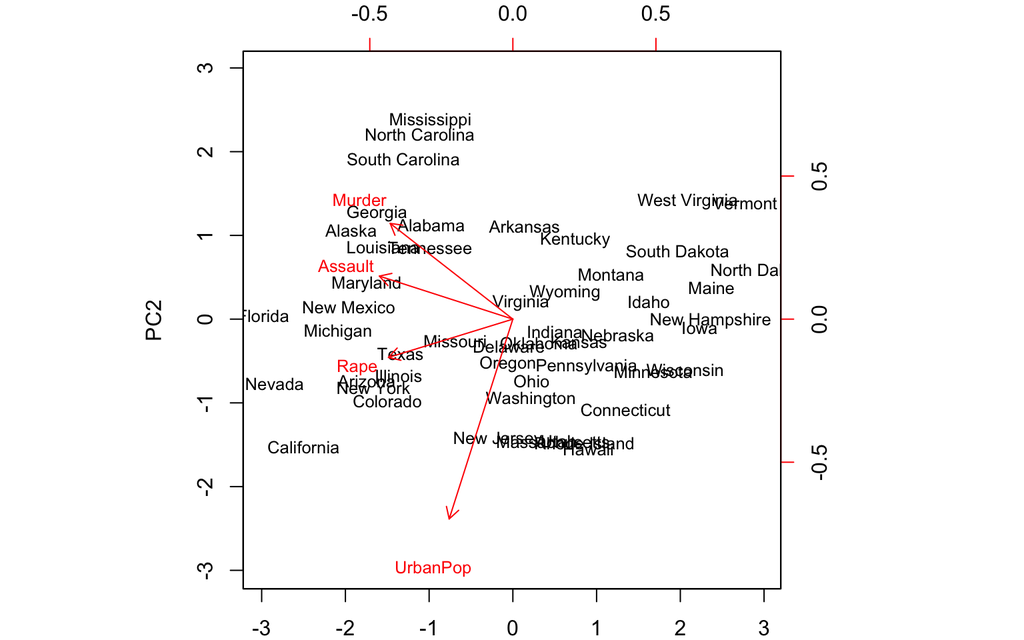

## How to interpret the Principal Components

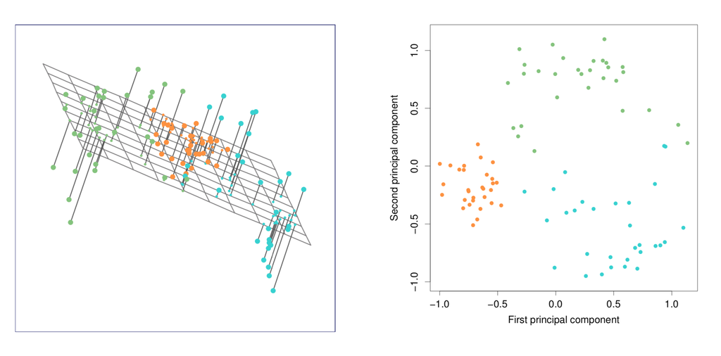

## How to interpret the Principal Components

- The first principal component loading vector has a very special property: it defines the line in \(p\)-dimensional space that is closest to the \(n\) observations (using average squared Euclidean distance)
- The notion of principal components as the dimensions that are closest to the \(n\) observations extends beyond just the first principal component
- For instance, the first two principal components of a data set span the plane that is closest to the \(n\) observations, in terms of average squared Euclidean distance

## Variable scaling

- If the variables are in different units, scaling each to have standard deviation equal to one is recommended
- If they are in the same units, you might or might not scale the variables

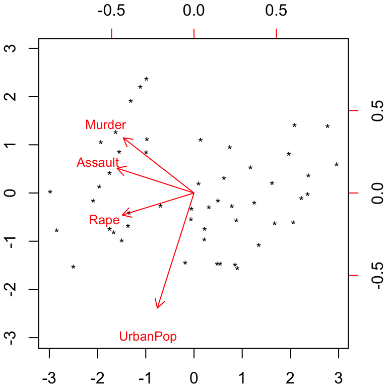

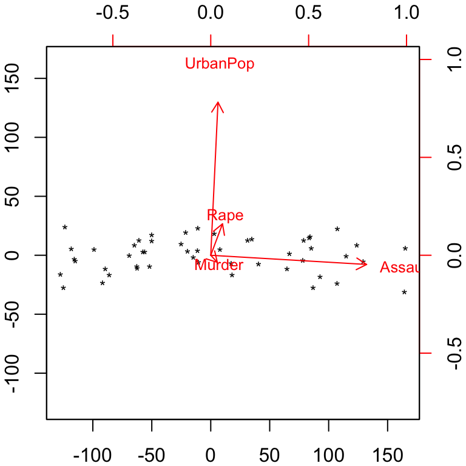

## Proportion of Variance

- To understand the strength of each component, we are interested in knowing the proportion of variance explained (PVE) by each one
- The total variance present in a data set (assuming that the variables have been centered to have mean zero) is defined as \[\sum_{j=1}^p \text{Var}(X_j) = \sum_{j=1}^p \frac{1}{n} \sum_{i=1}^n x_{ij}^2\] and the variance explained by the \(m{th}\) principal component is \[\text{Var}(Z_m) = \frac{1}{n} \sum_{i=1}^n z_{im}^2\]

## Proportion of Variance

The PVE of the \(m^{th}\) principal component is given by the positive quantity between 0 and 1 \[\dfrac{\sum_{i=1}^n z_{im}^2}{\sum_{j=1}^p \sum_{i=1}^n z_{ij}^2}\]

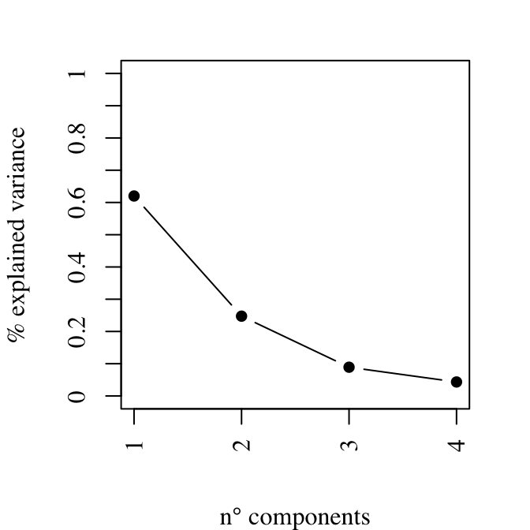

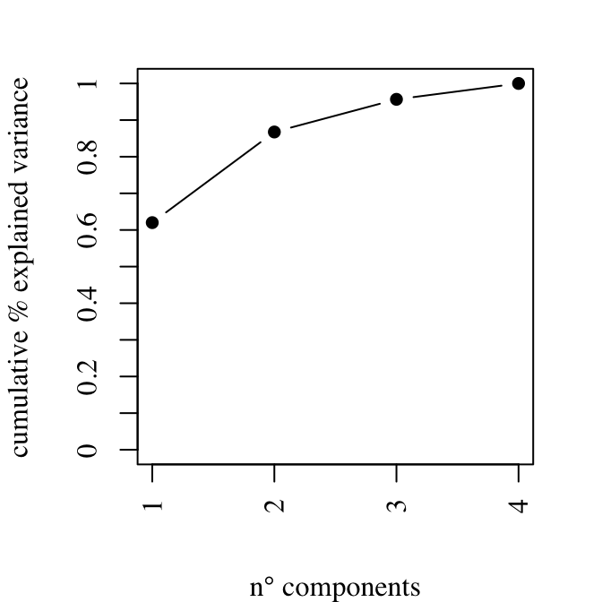